### Question 0

- Draw a concepts diagram that uses all the following Github terminology
  - Include any missing keywords that will simplify the concepts diagrams

`Push`, `Repository`, `Clone`, `Pull`, `Pull Request`, `Branch`, `Merging`, `Github Client`, `README file`, `Private or Public`

```r
library(magick)
```

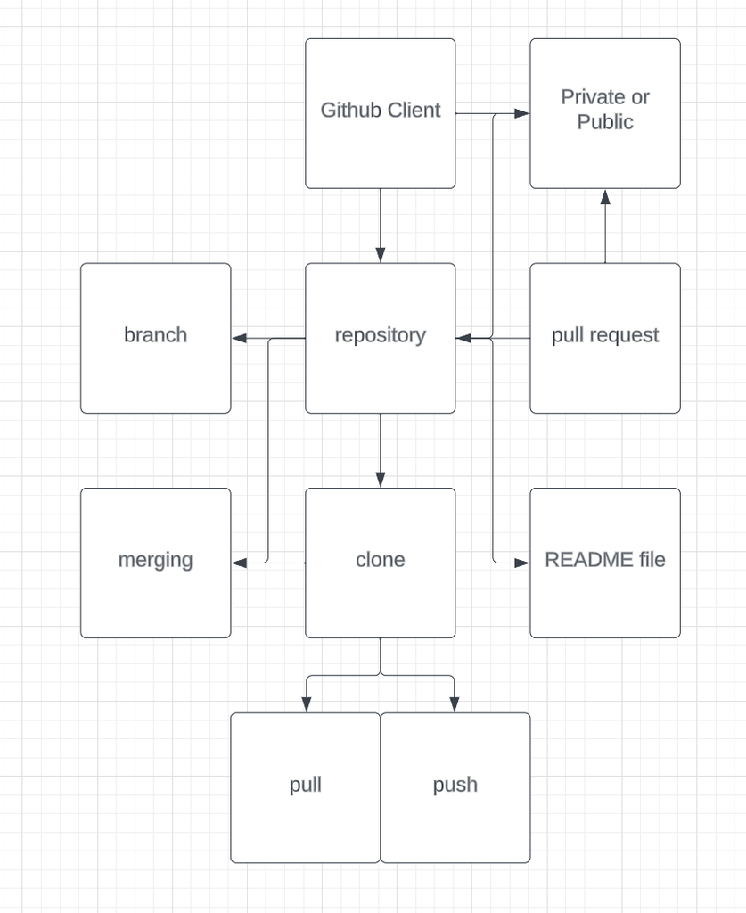

```r
# Specify the path to your .png file
png_path <- "Concept_Diagram_2.png"

# Read and display the .png image
image <- image_read(png_path)
image
```

#### Question 1

`matrix(c(1,2,3,4,5,6) , nrow = 3)`

- Running the expression produces the following matrix

| 1 | 4 |
| --- | --- |
| 2 | 5 |
| 3 | 6 |

- How can you modify the call to `matrix()` to produce the following matrix instead?

|  | col_1 | col_2 |
| --- | --- | --- |
| row_1 | 1 | 2 |
| row_2 | 3 | 4 |
| row_3 | 5 | 6 |

- Note that you need to name the columns (col_1 and col_2) and name the rows (row_1, row_2, row_3)

Hint: Use the `?` symbol to invoke the matrix documentation

```r
matrix <- matrix(c(1,2,3,4,5,6) , nrow = 3, byrow = TRUE)
colnames(matrix) <- c("col_1", "col_2")
rownames(matrix) <- c("row_1", "row_2", "row_3")
print(matrix)
```

```
##       col_1 col_2
## row_1     1     2
## row_2     3     4
## row_3     5     6
```

#### Question 2

- Load then sort the airquality data frame on its `Temp` and `Solar.R` columns in reverse order (largest to smallest values)
  - The function to sort a data frame is called order
- Display only the first 15 lines of your table

```r
# Write your answer here
data(airquality)

sorted_AQ <- airquality[order(-airquality$Temp, -airquality$Solar.R), ]

head(sorted_AQ, 15)
```

```
##     Ozone Solar.R Wind Temp Month Day
## 120    76     203  9.7   97     8  28
## 122    84     237  6.3   96     8  30
## 121   118     225  2.3   94     8  29
## 123    85     188  6.3   94     8  31
## 42     NA     259 10.9   93     6  11
## 127    91     189  4.6   93     9   4
## 126    73     183  2.8   93     9   3
## 70     97     272  5.7   92     7   9
## 69     97     267  6.3   92     7   8
## 43     NA     250  9.2   92     6  12
## 102    NA     222  8.6   92     8  10
## 125    78     197  5.1   92     9   2
## 75     NA     291 14.9   91     7  14
## 124    96     167  6.9   91     9   1
## 40     71     291 13.8   90     6   9
```

#### Question 3

- Sort the airquality data frame on its `Temp` in decreasing order and `Solar.R` in increasing order
- Display only the first 15 lines of your table

```r
data(airquality)

resorted_AQ <- airquality[order(-airquality$Temp, airquality$Solar.R), ]

head(sorted_AQ, 15)
```

[output not shown]

#### Question 4

- There are various ways to select a subset of observations from a data frame.
- Consult your [R Reference Card](https://cran.r-project.org/doc/contrib/Baggott-refcard-v2.pdf), see `Data Selection and Manipulation` section.
  - What operations can you use to select all observations where the temperature is 72. Give at least two different answers to this question

```r
##method1

data(airquality)
temp_72_obs_method1 <- subset(airquality, Temp == 72)
temp_72_obs_method1
```

```
##     Ozone Solar.R Wind Temp Month Day
## 2      36     118  8.0   72     5   2
## 48     37     284 20.7   72     6  17
## 114     9      36 14.3   72     8  22
```

```r
##Method2
data(airquality)
temp_72_indices <- which(airquality$Temp == 72)
temp_72_method2 <- airquality[temp_72_indices, ]
temp_72_method2
```

```
##     Ozone Solar.R Wind Temp Month Day
## 2      36     118  8.0   72     5   2
## 48     37     284 20.7   72     6  17
## 114     9      36 14.3   72     8  22
```

#### Question 6

- You may have noticed when working with the `airquality` data that some values show as `NA`
- `NA` stands for not available, or missing values.
- A major part of data wrangling consists of cleaning missing values by either:
  - Dropping the lines that have missing values
  - Sometimes we can drop the column with missing values if the column is made of predominantly missing values
  - Imputing the missing values, which uses educated guesses (or more complex algorithms) to fill the missing values
- Find and remove all rows that are missing values for the `Solar.R` or `Ozone` variables
- Save the cleaned data to a new data frame called airquality_no_na
  - How many lines have been removed?

```r
data("airquality")
airquality_no_na <- na.omit(airquality[, c("Solar.R", "Ozone")])
airquality_no_na
```

```
##     Solar.R Ozone
## 1       190    41
## 2       118    36
## 3       149    12
## 4       313    18
## 7       299    23
## 8        99    19
## 9        19     8
## 12      256    16
## 13      290    11
## 14      274    14
## 15       65    18
## 16      334    14
## 17      307    34
## 18       78     6
```

[output cut: 97 more lines]

```r
##42 lines were removed.
```

#### Question 7

- Let’s use a different strategy and impute the missing value.
  - replace the missing values for Solar.R using that month’s average.
  - Example:
    - The missing value for line 6 should be replaced with the average for month 5.
    - The missing value for line 97 should be replaced with the average for month 8.

```r
data(airquality)

impute_solar_r <- function(df) {
  monthly_mean_solar_r <- aggregate(Solar.R ~ Month, data = df, FUN = function(x) mean(x, na.rm = TRUE))
  df <- merge(df, monthly_mean_solar_r, by = "Month", suffixes = c("", "_mean"))
   df$Solar.R[is.na(df$Solar.R)] <- df$Solar.R_mean[is.na(df$Solar.R)]

  df <- df[, -c(7, 8)]

  return(df)
}

airquality_imputed <- impute_solar_r(airquality)

airquality_imputed
```

```
##     Month Ozone  Solar.R Wind Temp Day
## 1       5    41 190.0000  7.4   67   1
## 2       5    36 118.0000  8.0   72   2
## 3       5    12 149.0000 12.6   74   3
## 4       5    18 313.0000 11.5   62   4
## 5       5    NA 181.2963 14.3   56   5
## 6       5    28 181.2963 14.9   66   6
## 7       5    23 299.0000  8.6   65   7
## 8       5    19  99.0000 13.8   59   8
## 9       5     8  19.0000 20.1   61   9
## 10      5    NA 194.0000  8.6   69  10
## 11      5     7 181.2963  6.9   74  11
## 12      5    16 256.0000  9.7   69  12
## 13      5    11 290.0000  9.2   66  13
## 14      5    14 274.0000 10.9   68  14
```

[output cut: 139 more lines]